# Lab 9

Spicy Bois

10/17/2019

# How do factors like professor rank, discipline, years since phd, years of service and sex effect the salaries of professors?

### Why is it important/interesting

This question could help find trends and patterns within the salaries of professors to ensure that fair compensation is being provided, especially considering factors such as gender and seniority.

### Who is hiring us?

For the purpose of our the data we found, we are being asked by a college ethics board to analyze the salaries of several different types of professors to ensure equality and fairness in their compensations.

### Description of the Dataset

This Data set has 397 observations (professors) on the following 6 variables: rank, discipline, years since PHD, years of service, gender, and salary, from the accademic year 2008-09.

- **rank:** Associate Professor (AssocProf), Asstistant Proffessor (AsstProf), Proffessor (Prof)
- **discipline:** a factor with levels A (“theoretical” departments) or B (“applied” departments).
- **yrs.since.phd:** The years since professor got PhD.
- **yrs.service:** The years years the professor has worked/service.
- **sex:** Female or Male
- **salary:** nine-month salary, in dollars.

Data Source: https://vincentarelbundock.github.io/Rdatasets/datasets.html

Codebook Link: https://vincentarelbundock.github.io/Rdatasets/doc/carData/Salaries.html

## Individual Questions

### How do salaries of professors vary based on their rank? (Jack)

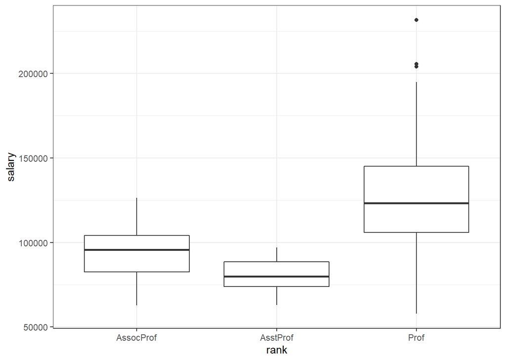

```r
dataBase <- read_csv("Salaries.csv")

Salaries <- dataBase %>% select(rank, salary)

ggplot(data = Salaries, mapping = aes(x = rank, y = salary)) + geom_boxplot() + theme_bw()
```

**Findings** : As expected, as the rank of the professor increases, so does the salary. The IQR of each rank is increases as the rank increases. However, professors have the largest range of values, some being even below both rankings. There are also outliers for the rank of professor on the top end of the range. Although, for the most part, as rank increases so does salary, there are values that contradict this for all ranks.

### How does the seniority of a professor impact their salary? (Trent)

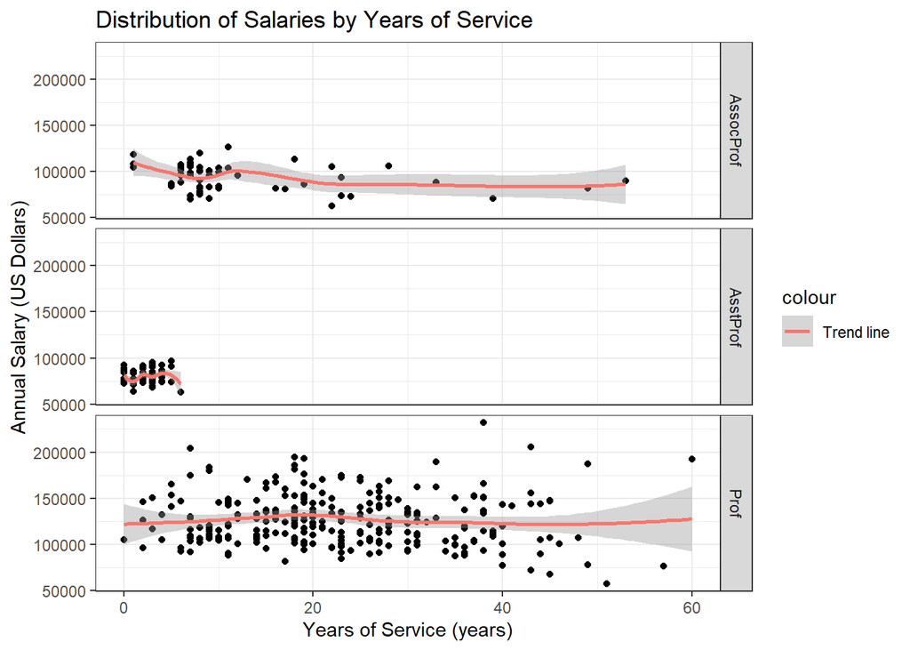

```r
data <- read_csv("Salaries.csv")
seniority <- data %>% select(yrs.service, salary)

ggplot(data) + geom_point(aes(x = yrs.service, y = salary)) + geom_smooth(aes(x = yrs.service, y = salary, color = 'Trend line')) + labs(title = "Distribution of Salaries by Years of Service", y = "Annual Salary (US Dollars)", x = "Years of Service (years)") + facet_grid(rank~ .) + theme_bw()
```

**Findings** : I faceted the graphs to show the distribution of salaries by years of service among the professors, associate professors, and assistant professors, due to the large difference between rankings. Initially I thought having more seniority would result in a higher wage, however, the trend is much more of a linear flatline. For example, there are professors who have been teaching for over 40 years who are still being payed less than a professor who has been teaching for less than 10 years. This could be a result of the type of material a professor teaches, but I would recommend that the ethics board should look into compensating the more senior professors a more, which would result in a more positive-sloped-trendline.

### Which discipline makes the most money? (Logan)

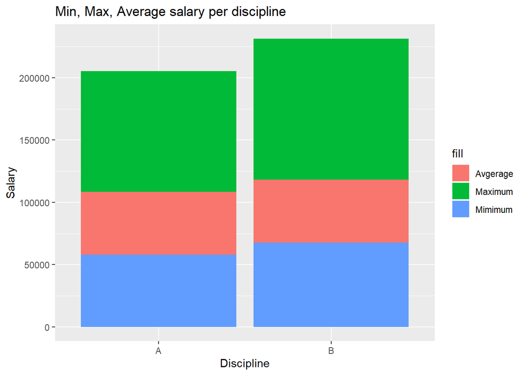

```r
data_disp <- read_csv("Salaries.csv")
data_disp <- data_disp %>%
  select(salary, discipline) %>%
  group_by(discipline) %>%
  summarise(min = min(salary), max = max(salary), avg = mean(salary))

ggplot(data_disp, aes(x = discipline)) +
  geom_col(aes(y = max, fill = "Maximum")) +
  geom_col(aes(y = avg, fill = "Avgerage")) +
  geom_col(aes(y = min, fill = "Mimimum")) +
  labs(title = "Min, Max, Average salary per discipline", x = "Discipline", y = "Salary")
```

**Finings:** The graph above shows that Discipline B, which is the applied depertments, gets payed more than Discipline A (theoretical depertments). This is stays true no matter if you look at the average, minimun, or maximun salary for each discipline.

### How does the gender of a professor impact their salary? (Joe)

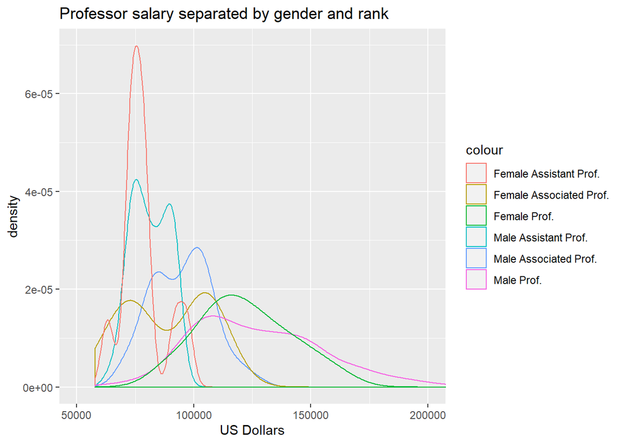

```r
library(tidyverse)
data <- read.csv('Salaries.csv')

yassdata <- data %>% select(sex, salary, rank) %>% filter(!is.na(rank)) %>% filter(rank == 'AssocProf') %>% filter( sex == 'Male')
plot1 <- yassdata$salary

xassdata <-data %>% select(sex, salary, rank) %>% filter(!is.na(rank)) %>% filter(rank == 'AssocProf') %>% filter( sex == 'Female')
plot2 <- xassdata$salary

yastdata <- data %>% select(sex, salary, rank) %>% filter(!is.na(rank)) %>% filter(rank == 'AsstProf') %>% filter( sex == 'Male')
plot3 <- yastdata$salary

xastdata <-data %>% select(sex, salary, rank) %>% filter(!is.na(rank)) %>% filter(rank == 'AsstProf') %>% filter( sex == 'Female')
plot4 <- xastdata$salary

yprofdata <- data %>% select(sex, salary, rank) %>% filter(!is.na(rank)) %>% filter(rank == 'Prof') %>% filter( sex == 'Male')
plot5 <- yprofdata$salary

xprofdata <- data %>% select(sex, salary, rank) %>% filter(!is.na(rank)) %>% filter(rank == 'Prof') %>% filter( sex == 'Female')
plot6 <- xprofdata$salary

ggplot()+
  geom_density(yassdata, mapping= aes(plot1, col= 'Male Associated Prof.'))+
  geom_density(xassdata, mapping= aes(plot2, color = 'Female Associated Prof.'))+
  geom_density(yastdata, mapping= aes(plot3, color = 'Male Assistant Prof.'))+
  geom_density(xastdata, mapping= aes(plot4, color= 'Female Assistant Prof.'))+
  geom_density(yprofdata, mapping= aes(plot5, color = 'Male Prof.'))+
  geom_density(xprofdata, mapping= aes(plot6, color = 'Female Prof.'))+
  coord_cartesian(xlim = c(50000, 200000))+
  xlab("US Dollars")+
  labs(title= "Professor salary separated by gender and rank")
```

### How does the amount of time a teacher has had their Phd effect their Slary? (Tyler)

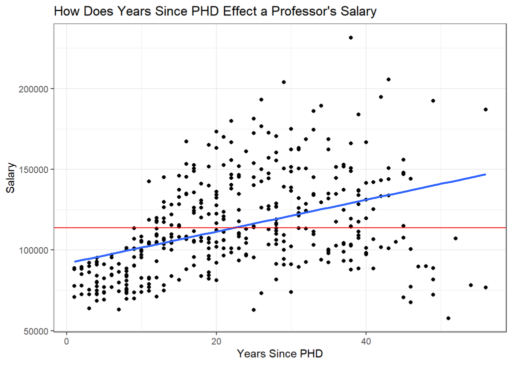

```r
data <- read_csv("Salaries.csv")

phd <- data %>% select(salary, yrs.since.phd)


ggplot(data = phd) + geom_point(aes(x = yrs.since.phd, y = salary)) +
  geom_smooth(aes(x = yrs.since.phd, y = salary), se = FALSE, method = lm) +
  geom_hline(yintercept = mean(phd$salary), color = 'red') +
  labs(title = "How Does Years Since PHD Effect a Professor's Salary", x = "Years Since PHD", y = "Salary") +
  theme_bw()
```

**Findings** :As I expected the salary increases for a Professor as the more years they have their PHD. However, I didn’t expect the spread of the of the salarys to increase the more years a professor has their PHD. Also, their are a few professors that have a lower salary then others that have had a PHD for less years then them. As well, professors tend to hit the mean salary after they have had their PHD for 23 years.

## Team Report

**Trent:** I graphed the relationship between years served and professor salary, and faceted it by professor type. I used a combination of geom_point and geom_smooth to present this data with a trendline. I also formatted the lab as a whole.

**Logan:** I graphed the min, max, and average salary for each discipline (theoretical vs. applied) to determine which proffessor of disciple get payed more. To do this I used the summerize function to calculate the minimum salary, maximum salary, and average salary.

**Tyler** For my individual graph, I graphed the years a teacher has had their PHD with their salary to see how the years since they got a PHD effects the salary. To do this I used a select funtion to select my data that I was going to use so I could make it simplier for me to work with the data.

**Jack**For my individual graph, I did how salaries of professors vary based on their rank. The data was already tidy so I just selected the columns I needed using the select function. For my graph, I used a box plot because it shows the salaries compared to the ranking the best. I kept it simple and just used the boxplot function from ggplot as well as a theme to change the graph background.